# apron_ty

## Import

Here I use dataset from https://www.kaggle.com/azathoth42/myanimelist It contains: basic information of 6668 anime (overall rating, number of episodes, airing year, genres, etc), information of 108711 users, and the rating they gave for each anime they???ve watched or watching.

```r
anime <- read.csv("clean/anime_cleaned.csv")
lists <- read.csv("clean/animelists_cleaned.csv")
```

```r
Anime <- anime %>%
  select("anime_id":"title", "type":"status", "rating":"popularity", "favorites", "studio", "genre", "duration_min":"aired_from_year") %>%
  filter(duration_min != 0)  %>%
  filter("scored_by" != 0)
```

```r
Lists <- lists %>%
  select("username", "anime_id", "my_score") %>%
  filter("my_score" != 0)
```

## Exploration

Overall distribution of ratings.

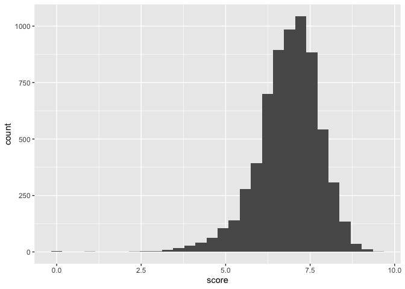

```r
ggplot(Anime) +
  geom_histogram(aes(score))
```

```r
head(arrange(Anime, score))
```

```
##   anime_id
## 1    37814
## 2    37860
## 3    37859
## 4    37858
## 5    37020
## 6      413
##                                                                title
## 1                     Inazuma Eleven Reloaded: Reformation of Soccer
## 2                    Free!: Take Your Marks: Character Butai Aisatsu
## 3 Free! Movie 2: Timeless Medley - Yakusoku: Character Butai Aisatsu
## 4   Free! Movie 1: Timeless Medley - Kizuna: Character Butai Aisatsu
## 5                                                         Woo to Wah
## 6                                                    Hametsu no Mars
##      type       source episodes           status
```

[output cut: 20 more lines]

```r
head(Anime %>%
    filter(episodes < 26&episodes >0) %>%
    arrange(score))
```

```
##   anime_id
## 1    37814
## 2    37860
## 3    37859
## 4    37858
## 5      413
## 6     5877
##                                                                title
## 1                     Inazuma Eleven Reloaded: Reformation of Soccer
## 2                    Free!: Take Your Marks: Character Butai Aisatsu
## 3 Free! Movie 2: Timeless Medley - Yakusoku: Character Butai Aisatsu
## 4   Free! Movie 1: Timeless Medley - Kizuna: Character Butai Aisatsu
## 5                                                    Hametsu no Mars
## 6                                        Abunai Sisters: Koko & Mika
##      type       source episodes          status
```

[output cut: 27 more lines]

This part does not have so much connection with building the recommendation system but I???m interested??? People always say that light novels??? adoption is the worst. But here it shows not really.

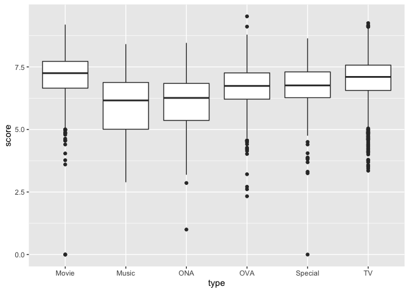

```r
ggplot(Anime) +
  geom_boxplot(aes(type, score))
```

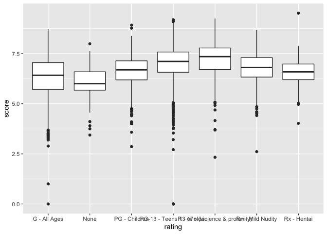

```r
ggplot(Anime) +
  geom_boxplot(aes(rating, score))
```

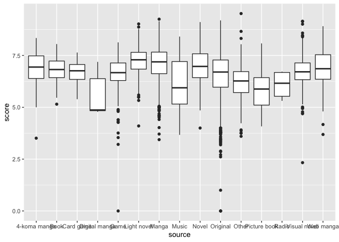

```r
ggplot(Anime) +
  geom_boxplot(aes(source, score))
```

## Some Preprocessing

Split the genre column in Anime into a data frame (where 1 means an anime belongs to this genre and 0 means it does not)

```r
genres <- as.data.frame(Anime$genre, stringsAsFactors=FALSE)
genres2 <- as.data.frame(tstrsplit(genres[,1], '[,]',
                                   type.convert=TRUE),
                         stringsAsFactors=FALSE)
colnames(genres2) <- c(1:13)
```

```r
genre_list <- c("Action", "Adventure", "Cars", "Comedy", "Dementia","Demons", "Drama", "Ecchi", "Fantasy","Game", "Harem", "Hentai", "Historical","Horror", "Josei", "Kids", "Magic", "Martial Arts", "Mecha", "Military", "Music", "Mystery", "Parody", "Police", "Psychological", "Romance", "Samurai", "School", "Sci-Fi", "Seinen", "Shoujo", "Shoujo Ai", "Slice of Life", "Space", "Sports", "Super Power", "Supernatural", "Thriller", "Vampire", "Yaoi", "Yuri")
```

```r
genre_matrix <- matrix(0,6622,41)
genre_matrix[1,] <- genre_list
colnames(genre_matrix) <- genre_list
for (i in 1:nrow(genres2)) {
  for (c in 1:ncol(genres2)) {
    genmat_col = which(genre_matrix[1,] == genres2[i,c])
    genre_matrix[i+1, genmat_col] <- 1
  }
}
```

```r
genre_matrix2 <- as.data.frame(genre_matrix[-1,], stringsAsFactors=FALSE)
for (c in 1:ncol(genre_matrix2)) {
  genre_matrix2[,c] <- as.integer(genre_matrix2[,c])
}
```

Rejoin this with the anime data frame.

```r
anime_index <- cbind(Anime, genre_matrix2)
```

## User based collaborative filtering

Basic idea of UBCF: 1. Creating a matrix that has username as rows and anime_id as columns, and ratings as entries. 2. Some transformation to reduce the magnitude of the matrix/normalization 3. For each user, find users who have ???similar taste??? to him/her, then use their rating to recommend animes to him/her. I will use a package called recommenderlab to do this.

First of all, transform the data frame to a matrix for recommender lab to work.

```r
ratingmat <- dcast(Lists, username~anime_id, value.var = "my_score", na.rm=FALSE)
ratingmat <- as.matrix(ratingmat[,-1])
ratingmat <- as(ratingmat, "realRatingMatrix")
```

### Some visualization

Similarity between users:

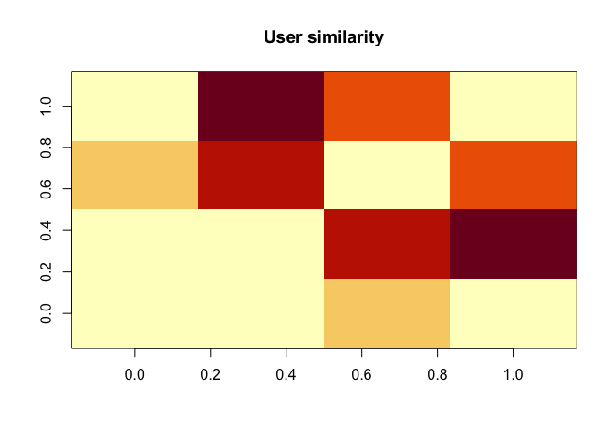

```r
similarity_users <- similarity(ratingmat[1:4, ],
                               method = "cosine",
                               which = "users")
similarity_users <- as.matrix(similarity_users)
image(as.matrix(similarity_users), main = "User similarity")
```

### Pre-process

Here I select users who have watched enough animes to make recommendation (and animes with enough ratings, intended to use for item-based collaborative filtering)

```r
ratingmat2 <- ratingmat[rowCounts(ratingmat) > 15, colCounts(ratingmat) > 100]
```

#### Normalization

```r
ratingmat3 <- normalize(ratingmat2)
sum(rowMeans(ratingmat3) > 0.1)
```

```
## [1] 0
```

#### Binarization

Because the MAL has ratings from 1 to 10, and the matrix is quite large (6000*9000), so binarization can reduce its size for making models.

```r
ratingmat4 <- binarize(ratingmat3, minRating = 0)
```

This set is just to make sure again each person have enough positive values for making the model.

```r
ratingmat5 <- ratingmat4[rowSums(ratingmat4) > 6,]
```

#### Splitting

```r
eval_sets = evaluationScheme(data = ratingmat5, method = "split", train = 0.8, given = -5)
```

```r
eval_sets1 = evaluationScheme(data = ratingmat5[1:10000,], method = "split", train = 0.8, given = -5)
```

### Building Rec

```r
user_recommender = Recommender(data = getData(eval_sets1, "train"),
                               method = "UBCF", parameter = NULL)
```

```r
getModel(user_recommender)
```

```
## $description
## [1] "UBCF-Binary Data: contains full or sample of data set"
##
## $data
## 8000 x 5846 rating matrix of class 'binaryRatingMatrix' with 1382923 ratings.
##
## $method
## [1] "jaccard"
##
## $nn
## [1] 25
##
## $weighted
## [1] TRUE
##
## $sample
## [1] FALSE
##
## $verbose
## [1] FALSE
```

Use it to make prediction:

```r
user_prediction = predict(object = user_recommender,
                          newdata = getData(eval_sets1, "known"),
                          n = 1,
                          type = "ratings")
```

Calculate its accuracy:

```r
user_pred <- getTopNLists(x = user_prediction, n=5)
```

```r
user_accuracy = calcPredictionAccuracy(x = user_pred, given = 5,
                                       data = getData(eval_sets1, "unknown"), byUser=T)
user_accuracy
```

```
##       TP FP FN   TN precision recall TPR          FPR
## 2      0  5  5 5831       0.0    0.0 0.0 0.0008567512
## 7      1  4  4 5832       0.2    0.2 0.2 0.0006854010
## 10     1  4  4 5832       0.2    0.2 0.2 0.0006854010
## 11     0  5  5 5831       0.0    0.0 0.0 0.0008567512
## 12     0  5  5 5831       0.0    0.0 0.0 0.0008567512
## 18     1  4  4 5832       0.2    0.2 0.2 0.0006854010
## 26     1  4  4 5832       0.2    0.2 0.2 0.0006854010
## 63     1  4  4 5832       0.2    0.2 0.2 0.0006854010
## 66     2  3  3 5833       0.4    0.4 0.4 0.0005140507
## 67     0  5  5 5831       0.0    0.0 0.0 0.0008567512
## 71     0  5  5 5831       0.0    0.0 0.0 0.0008567512
## 72     1  4  4 5832       0.2    0.2 0.2 0.0006854010
## 79     0  5  5 5831       0.0    0.0 0.0 0.0008567512
## 93     1  4  4 5832       0.2    0.2 0.2 0.0006854010
```

[output cut: 1986 more lines]

## Item Based Collaborative Filtering

IBCF’s idea is basically the same as UBCF, but takes much much longer time…

```r
# item_recommender = Recommender(data = getData(eval_sets1, "train"),
#                                method = "IBCF", parameter = NULL)
```

```r
# getModel(item_recommender)
```

Use it to make prediction:

```r
# item_prediction = predict(object = item_recommender,
#                          newdata = getData(eval_sets1, "known"),
#                          n = 1,
#                          type = "ratings")
```

Calculate its accuracy:

```r
# item_pred <- getTopNLists(x = item_prediction, n = 200)
```

```r
# item_accuracy = calcPredictionAccuracy(x = user_pred, given = 200,
#                                        data = getData(eval_sets1, "unknown"), byUser=T)
# item_accuracy
```

## Comparison with models with other parameters

```r
models_to_evaluate = list(UBCF_cos = list(name = "UBCF", param = list(method = "cosine")),
                          UBCF_cor = list(name = "UBCF", param = list(method = "pearson")),
                          random = list(name = "RANDOM", param=NULL))
n_recommendations = c(1, 3, 5, 10)
results = evaluate(x = eval_sets1, method = models_to_evaluate, n = n_recommendations)
```

```
## UBCF run fold/sample [model time/prediction time]
##   1  [0.002sec/192.541sec]
## UBCF run fold/sample [model time/prediction time]
##   1  [0.004sec/271.814sec]
## RANDOM run fold/sample [model time/prediction time]
##   1  [0.007sec/65.834sec]
```

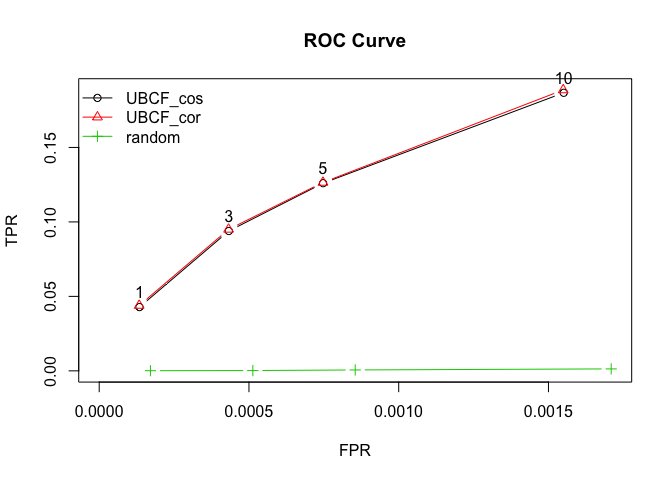

```r
plot(results, y = "ROC", annotate = 1, legend="topleft")
title("ROC Curve")
```

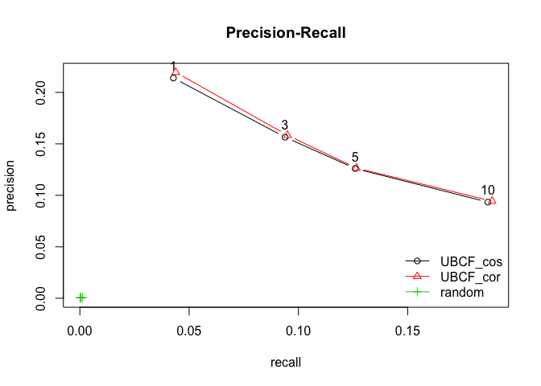

```r
plot(results, y = "prec/rec", annotate=1)
title("Precision-Recall")
```

## Item rec based on Anime/user info

The idea is to do clustering on animes based on their genre, studio, airing year. Then recommend animes in the same cluster to the user.

There is a data frame contains the age, gender, etc., of the user. This info may be useful for recommendation.